# Peribahasa Viz

aishah

February 24, 2022

### Reacquainting myself with Malay Peribahasa

(through data vis)

Hi! This is short after work project that I’ve done from (21-24 Feb 2022)

```r
# Import libraries
library(ggplot2)
library(tidyverse)
library(dplyr)
library(tidytext)
library(stringr)
library(udpipe)
library(malaytextr)
```

#### How students from primary schools to junior colleges are scoring for their Mother Tongue

This dataset plots percentage of passes for Mother Tongue language over the years and tagged to ethnic group. The general trend across the years is a decreasing one. While we are still above 95% passes across all levels, the decreasing % trend when superimposed onto the ethnic Malay demographic questions why are more people failing their own Mother Tongue language.

Caveats: - This fails to account for student who don’t identify as Malay (e.g. mixed-race students who still take Malay). - This assumes that if you put Malay as your ethnicity, you are taking Malay language for your Mother Tongue. - Note that for PSLE it’s listed as (A* - C).

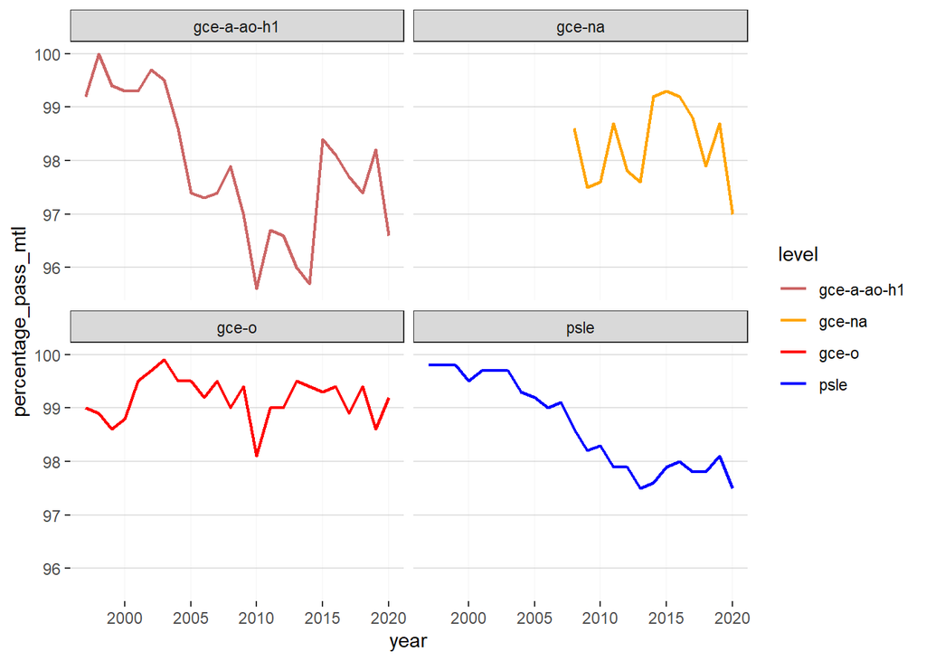

```r
pass <- read.csv(file = './pass.csv', header = TRUE)
pass %>%
  filter(race == 'Malay' & level != "gce-nt") %>%
  ggplot(aes(x = year, y = percentage_pass_mtl, color = level)) +
  geom_line(size = 0.8) + theme_bw() +
  theme(
    panel.border = element_blank(),
    panel.background = element_blank(),
    panel.grid.minor = element_blank(),
    panel.grid.major.x = element_line(color = '#C4C4C41A'),
    panel.grid.major.y = element_line(color = '#C4C4C47F')
  ) +
  scale_color_manual(values=c("#CC6666", "orange", 'red', 'blue', 'green')) +
  facet_wrap( ~ level, ncol = 2)
```

It’s always been a given and easy subject to score as long as you speak it at home or with your grandparents. I mean, it’s hard to fail Malay if you are are Melayu. Kalau tak belajar pun, masih boleh pass.

Kan?

The most worrying part is the PSLE graph – it probably aligns with the desas-desus that younger Malay Singaporeans are getting out of touch with the Malay language.

And that got me thinking, in the entire Malay paper, what are the things that you need to hafal? - Peribahasa definitely. - Penjodoh bilangan, yes. - Kamus Dewan? Kidding, tak perlu.

While peribahasa constitutes only a small component of the Malay paper across all levels, I thought peribahasa is good entry point into visualising something unique to the Malay language.

And maybe just coz it’s wacky enough for people to get interested in the getting to know this aspect of the Malay language.

#### Analysing peribahasa list from Wikipedia Malaysia

The following is the results of the exploratory data analysis on peribahasa.

```r
# Import data
peri_csv <- read.csv(file = './peri.csv', header = TRUE)
peri_csv$Peribahasa <- gsub("\\s*\\([^\\)]+\\)", "", as.character(peri_csv$Peribahasa))
peri_csv$Peribahasa <- tolower(peri_csv$Peribahasa)
peri_csv$Makannya <- gsub("\\s*\\([^\\)]+\\)", "", as.character(peri_csv$Makannya))

peri_csv_clean <- peri_csv %>% filter(!str_detect(Peribahasa, '='))
peri_csv_clean$Peribahasa <- str_replace_all(peri_csv_clean$Peribahasa, ':', ',')

peri_csv %>% head()
```

|  | Peribahasa | Makannya |
| --- | --- | --- |
| 1 | ada air, adalah ikan | Ada penempatan adalah penduduk. |
| 2 | ada aku dipandang hadap, tiada aku dipandang belakang | Kasih sayang hanya waktu berhadapan saja, setelah berjauhan lalu dilupakan. |
| 3 | ada angin, ada pokoknya | Segala sesuatu mestilah ada asal mulanya. |
| 4 | ada bangkai, adalah hering | Ada perempuan jahat, adalah lelaki jahat yang mengunjunginya. |
| 5 | ada batang mati, adalah cendawan tumbuh | Di mana juga kita tinggal, akan ada rezeki kita. |
| 6 | ada batang, cendawan tumbuh | Tiap-tiap negeri ada undang-undang dan adat resamnya masing-masing. |

The dataset is scraped from Wikipedia pages Senarai peribahasa (A-M) and Senarai peribahasa (N–Z). They’ve already been tabulated into peribahasa and its corresponding meaning.

Data cleaning the peribahasa removes instances where the author writes some translation between brackets within the peribahasa entries.

After which we execute the following steps to analyse this dataset:

- Tokenising each peribahasa into its own word
- Each word is reduced to its root word
- Removing the stop words like ‘dan’ from the list of root words

```r
# tokenising malay words
tokenised <- tibble(line = 1:2286, text = peri_csv_clean$Peribahasa) %>%
  unnest_tokens(word, text)

# cleaning the stop words first, then changing to root words
tokenised %>%
#  anti_join(malaystopwords, by = c("word" = "stopwords")) %>%
  group_by(word) %>%
  count() %>%
  arrange(desc(n))
```

| word | n |
| --- | --- |
| di | 394 |
| bagai | 289 |
| yang | 217 |
| tak | 176 |
| ke | 170 |
| hendak | 117 |
| air | 104 |
| tidak | 97 |
| ada | 93 |
| orang | 92 |

[output cut: 3480 more lines]

```r
# changing to root words and cleaning away stop words
tokenised_root_clean <- tokenised %>%
  stem_malay(dictionary = malayrootwords,
             col_feature1 = "word") %>%
  anti_join(malaystopwords, by = c("Root Word" = "stopwords"))
```

```
## 'Root Word' is now returned instead of 'root_word'
```

```r
### This means when I change to root words, it increases the number of stopwords and hence they get shaved.

# bigram for words that coincide together
tibble(line = 1:2286, text = peri_csv_clean$Peribahasa) %>%
  unnest_tokens(ngram, text, token = "ngrams", n = 2) %>%
  group_by(ngram) %>%
  count() %>%
  arrange(desc(n)) %>% head(20)
```

| ngram | n |
| --- | --- |
| di dalam | 28 |
| di mana | 21 |
| di atas | 20 |
| di tengah | 18 |
| tak dapat | 15 |
| di luar | 14 |
| jatuh ke | 14 |
| di situ | 13 |
| di bawah | 12 |
| bagai ayam | 11 |

[output cut: 10 more lines]

Using Indonesian dictionary from UDpipe to add parts-of-speech tagging to the list of cleaned tokenised words

```r
indo   <- udpipe::udpipe_download_model(language = "indonesian-gsd")
```

```
##  - This model has been trained on version 2.5 of data from https://universaldependencies.org
```

```
##  - The model is distributed under the CC-BY-SA-NC license: https://creativecommons.org/licenses/by-nc-sa/4.0
```

```
##  - Visit https://github.com/jwijffels/udpipe.models.ud.2.5 for model license details.
```

[output not shown]

```r
indo_dict <- udpipe_load_model(file = "./indonesian-gsd-ud-2.5-191206.udpipe")

pos_peri <- udpipe::udpipe_annotate(indo_dict, x = peri_csv_clean$Peribahasa) %>%
  as.data.frame()

pos_peri_clean <- pos_peri %>%
  mutate(id = str_extract(doc_id, "[^doc]+$")) %>%
  select(id, sentence, token_id, lemma, upos) %>%
  #anti_join(malaystopwords, by = c("lemma" = "stopwords")) %>%
  filter(upos != 'PUNCT') %>%
  stem_malay(dictionary = malayrootwords,
             col_feature1 = "lemma")
```

```
## 'Root Word' is now returned instead of 'root_word'
```

```r
pos_peri_clean %>% head()
```

|  | id | sentence | token_id | Col Word | upos | Root Word |
| --- | --- | --- | --- | --- | --- | --- |
| 1 | 1 | ada air, adalah ikan | 1 | ada | verb | ada |
| 2 | 1 | ada air, adalah ikan | 2 | air | noun | air |
| 3 | 1 | ada air, adalah ikan | 4 | adalah | aux | adalah |
| 4 | 1 | ada air, adalah ikan | 5 | ikan | noun | ikan |
| 5 | 2 | ada aku dipandang hadap, tiada aku dipandang belakang | 1 | ada | verb | ada |
| 6 | 2 | ada aku dipandang hadap, tiada aku dipandang belakang | 2 | aku | pron | aku |

We can also divide the part of speech into nouns, verbs and adj. I think the nouns and verbs will come in handy in the later part.

```r
# nouns
nouns <- pos_peri_clean %>% filter(upos == 'noun') %>% group_by(`Col Word`, `Root Word`) %>% count() %>% arrange(desc(n))
#nouns %>% View()
#write.csv(nouns, 'nouns.csv')

# verb
verbs <- pos_peri_clean %>% filter(upos == 'verb') %>% group_by(`Col Word`, `Root Word`) %>% count() %>% arrange(desc(n))

# adj
adj <- pos_peri_clean %>% filter(upos == 'adj') %>% group_by(`Col Word`, `Root Word`) %>% count() %>% arrange(desc(n))
```

#### Trying ti-idf on the makna column

- Term Frequency: is a scoring of the frequency of the word in the current document.
- Inverse Document Frequency: is a scoring of how rare the word is across documents.
- A high weight in tf–idf is reached by a high term frequency (in the given document) and a low document frequency of the term in the whole collection of documents; the weights hence tend to filter out common terms.

(ERM,doesn’t it mean for a shorter review, the TF is higher and if it so happened they use gibberish that is unique, the IDF will be higher also constituing a high tf_idf value in the end?)

```r
# Doing a TI-IDF on the makna coloumn

words <- tibble(line = 1:2286, text = peri_csv_clean$Makannya) %>%
  unnest_tokens(word, text) %>%
  count(line, word)

total_words <- words %>%
  group_by(line) %>%
  summarize(total = sum(n))

words <- left_join(words, total_words)
results <- words %>% bind_tf_idf(word, line, n)

results %>% group_by(line) %>% top_n(2, wt = tf_idf) %>% anti_join(malaystopwords, by = c("word" = "stopwords")) %>%
  stem_malay(dictionary = malayrootwords,
             col_feature1 = "word")
```

```
## `mutate_all()` ignored the following grouping variables:
## Column `line`
## Use `mutate_at(df, vars(-group_cols()), myoperation)` to silence the message.
```

```
## 'Root Word' is now returned instead of 'root_word'
```

| line | Col Word | n | total | tf | idf | tf_idf | Root Word |
| --- | --- | --- | --- | --- | --- | --- | --- |
| 1 | penempatan | 1 | 4 | 0.25 | 7.73455884435476 | 1.93363971108869 | empat |
| 2 | berhadapan | 1 | 10 | 0.1 | 6.63594655568665 | 0.663594655568665 | hadap |
| 2 | berjauhan | 1 | 10 | 0.1 | 6.34826448323486 | 0.634826448323487 | jauh |
| 2 | dilupakan | 1 | 10 | 0.1 | 6.34826448323486 | 0.634826448323487 | lupa |
| 3 | mestilah | 1 | 6 | 0.166666666666667 | 5.78864869529944 | 0.964774782549907 | sti |
| 3 | mulanya | 1 | 6 | 0.166666666666667 | 6.63594655568665 | 1.10599109261444 | mula |
| 4 | mengunjunginya | 1 | 8 | 0.125 | 7.73455884435476 | 0.966819855544344 | kunjung |
| 5 | tinggal | 1 | 9 | 0.111111111111111 | 5.0955015147395 | 0.566166834971055 | tinggal |
| 6 | undang | 2 | 11 | 0.181818181818182 | 6.12512093192066 | 1.1136583512583 | undang |
| 7 | disimpan | 1 | 5 | 0.2 | 5.53733426701854 | 1.10746685340371 | simp |

[output cut: 4097 more lines]

```r
# Doing a TI-IDF on peribahasa to see what weightage works

peri_csv_clean$Peribahasa_ganda = str_replace_all(peri_csv_clean$Peribahasa, '-', '_')

words_p <- tibble(line = 1:2286, text = peri_csv_clean$Peribahasa_ganda) %>%
  unnest_tokens(word, text) %>%
  count(line, word)

total_words_p <- words_p %>%
  group_by(line) %>%
  summarize(total = sum(n))

words_p <- left_join(words_p, total_words_p)
# this is good
words_p %>% bind_tf_idf(word, line, n) %>% group_by(line) %>% top_n(2, wt = tf_idf) %>% anti_join(malaystopwords, by = c("word" = "stopwords"))
```

| line | word | n | total | tf | idf | tf_idf |
| --- | --- | --- | --- | --- | --- | --- |
| 1 | ikan | 1 | 4 | 0.25000000 | 4.151040 | 1.0377600 |
| 2 | dipandang | 2 | 8 | 0.25000000 | 5.942799 | 1.4856998 |
| 3 | pokoknya | 1 | 4 | 0.25000000 | 7.734559 | 1.9336397 |
| 4 | hering | 1 | 4 | 0.25000000 | 7.734559 | 1.9336397 |
| 5 | cendawan | 1 | 6 | 0.16666667 | 6.348264 | 1.0580441 |
| 6 | batang | 1 | 4 | 0.25000000 | 4.901346 | 1.2253364 |
| 6 | cendawan | 1 | 4 | 0.25000000 | 6.348264 | 1.5870661 |
| 6 | tumbuh | 1 | 4 | 0.25000000 | 4.901346 | 1.2253364 |
| 7 | beras | 1 | 5 | 0.20000000 | 6.348264 | 1.2696529 |
| 7 | taruh | 1 | 5 | 0.20000000 | 7.041412 | 1.4082823 |

[output cut: 4511 more lines]

```r
words_p %>% bind_tf_idf(word, line, n) %>% group_by(line) %>% top_n(2, wt = tf_idf) %>% anti_join(malaystopwords, by = c("word" = "stopwords")) %>% arrange(desc(tf_idf))
```

| line | word | n | total | tf | idf | tf_idf |
| --- | --- | --- | --- | --- | --- | --- |
| 40 | agih_agih | 1 | 2 | 0.50000000 | 7.734559 | 3.8672794 |
| 40 | kungkang | 1 | 2 | 0.50000000 | 7.734559 | 3.8672794 |
| 110 | amak | 2 | 4 | 0.50000000 | 7.734559 | 3.8672794 |
| 583 | sekuku | 1 | 2 | 0.50000000 | 7.734559 | 3.8672794 |
| 602 | kerongkongan | 1 | 2 | 0.50000000 | 7.734559 | 3.8672794 |
| 689 | berkandilkan | 1 | 2 | 0.50000000 | 7.734559 | 3.8672794 |
| 703 | berkelambukan | 1 | 2 | 0.50000000 | 7.734559 | 3.8672794 |
| 717 | berkotakan | 1 | 2 | 0.50000000 | 7.734559 | 3.8672794 |
| 803 | berkeesaan | 1 | 2 | 0.50000000 | 7.734559 | 3.8672794 |
| 840 | daunkeladi | 1 | 2 | 0.50000000 | 7.734559 | 3.8672794 |

[output cut: 4511 more lines]

#### Other types of analysis and exploration

1. Length of peribahasa

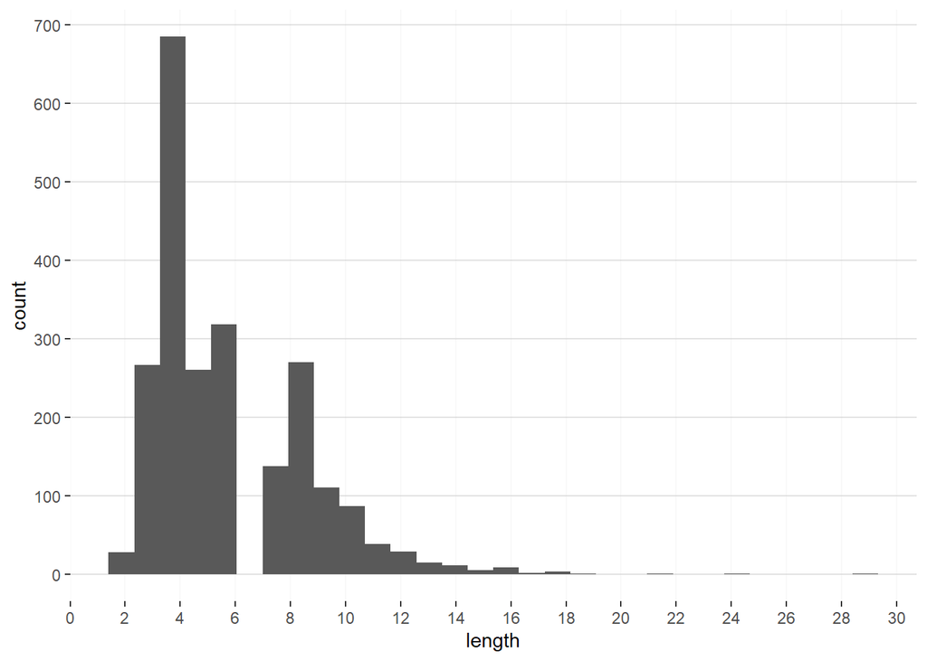

```r
peri_csv_clean %>%
  mutate(length = str_count(Peribahasa, '\\w+')) %>%
  ggplot(aes(length)) +
  geom_histogram(bins=30) +
  theme_bw() +
  theme(
    panel.border = element_blank(),
    panel.background = element_blank(),
    panel.grid.minor = element_blank(),
    panel.grid.major.x = element_line(color = '#C4C4C41A'),
    panel.grid.major.y = element_line(color = '#C4C4C47F')
  ) +
  scale_x_continuous(breaks = seq(0, 30, by = 2)) +
  scale_y_continuous(breaks = seq(0, 700, by = 100))
```

2. Peribahasa itu simile?

Apparently there are 4 types of peribahasa: simpulan, bidalan, perumpamaan & pepatah. (ikr Im shooketh) But I think perumpamaan is the type that we normally associate peribahasa with.

They are recognised by the comparitive words like “bagai”, “seperti”, “laksama”.

```r
perumpamaan <- c("bagai", "seperti", "laksama", "umpama", "ibarat", paste0('\\b', 'bak ', '\\b'))

peri_csv_clean %>%
  mutate(length = str_count(Peribahasa, '\\w+')) %>%
  mutate(type = if_else(str_detect(Peribahasa, paste(perumpamaan, collapse = "|")), 'Perumpamaan', '')) %>%
  filter(type == "Perumpamaan") %>%
  arrange(length)
```

| Peribahasa | Makannya | Peribahasa_ganda | length | type |
| --- | --- | --- | --- | --- |
| bagai anak nangui | Berbaring dan bermalas-malas saja di rumah orang lain. | bagai anak nangui | 3 | Perumpamaan |
| bagai ara hanyut | Satu sama lain bertolong-tolongan. | bagai ara hanyut | 3 | Perumpamaan |
| bagai balak terendam | Orang gemuk yang malas bergerak. | bagai balak terendam | 3 | Perumpamaan |
| bagai belut diregang | Tinggi dan kurus. | bagai belut diregang | 3 | Perumpamaan |
| bagai buntal kembung | Bodoh dan sombong. | bagai buntal kembung | 3 | Perumpamaan |
| bagai cacing gila | Perempuan yang suka berpergian, bertandang dan sebagainya. | bagai cacing gila | 3 | Perumpamaan |
| bagai galah dijual | Terlalu miskin; kalah judi. | bagai galah dijual | 3 | Perumpamaan |
| bagai gelegar buluh | Bercakap besar. | bagai gelegar buluh | 3 | Perumpamaan |
| bagai gulai lengkitang | Hendak menghilangkan kejahatan dirinya, tetapi kebaikan yang ada padanya pun lenyap pula. | bagai gulai lengkitang | 3 | Perumpamaan |
| bagai kacang direndang | Bunyi suara yang tak putus-putus. | bagai kacang direndang | 3 | Perumpamaan |

[output cut: 366 more lines]

3. Nature, binatang, body parts

I took the liberty of accessing the Nouns csv to see what are the common nouns that are used in Peribahasa.

They can be categorised into: Nature-related stuff, binatang, body parts. For example, nature-related stuff would be lautan, padi, langit, ombak. I think it signposts to how we live off the sea at one point coz archipelago eh?

Another research paper says that peribahasa is strongly tied to our person and values. Much of the comparison draws back to orang-related and orang, hati and anak is one of the most frequently occuring nouns.

And of course, binatang. I think it’s cool that gajah makes the top list coz DO WE HAVE GAJAH IN SINGAPORE? Apparently in Johor have and they have once or twice swam across that causeway to Ubin and Tekong. But also these peribahasa are from all over the Malay land so Malaysia got gajah lah.

Harimau gets featured too! But not Singa.

Spotlight on anjing, ayam and kucing, maybe tikus. Further reading confirms my hypothesis that peribahasa featuring anjing are oftentimes related to deter people from bad values. Does it tie to the Islamisation of Malay people coz anjing najis. (but I love doggos uwu)

I guess another cateogory that I can find is food like nasi, and some other buah2. I like to think of it as a representation of how Malay people used to have dusun at kampong but I think at this point I’m over-reaching.

```r
nouns %>% filter(`Col Word` != 'bak' & `Col Word` != 'laksana') %>% head(20)
```

| Col Word | Root Word | n |
| --- | --- | --- |
| air | air | 108 |
| orang | orang | 92 |
| anak | anak | 74 |
| ayam | ayam | 61 |
| hati | hati | 49 |
| ikan | ikan | 43 |
| gajah | gajah | 39 |
| kain | kain | 37 |
| kaki | kaki | 33 |
| tangan | tang | 33 |

[output cut: 10 more lines]

#### Dengan itu

A summary of what we can do with this dataset: - 1. Finding word frequency of root words from the table - 2. Comparing root words with respect to list of animals/nature/body parts - 3. Comparing results if we used udpipe on Indonesian Dictionary - 4. Finding the common structures of peribahasa - what is the average length of a peribahasa? - 5. Unique words (lowest frequency) word cloud - hello I think this is important to see the words that we don’t use anymore?